# Exercise_4_Readman_

## Exercise 4: Factor Variables, CPS-ORG/CPI Data, 1982–2024

Peter Readman

### Plan

- Use the Merged CPS-ORG/CPI Data from Exercise 3
- Estimate a Simple log-Wage Regression
- Add Factor Variables
- Estimate Year-Specific Grade Coefficients
- Merge the Grade Coefficients with the 90-10 Differential (in logs)
- Plot the Relationship Between the Grade Coefficients and the 90-10 Differential

### Preliminaries

First, let’s navigate to the analysis folder and set up some global macros. For this exercise, it’s going to be useful to have macros for the start year, end year, and number of years covered by our sample.

```stata
. cd "~/Dropbox/@10,000 feet and Runway/MA in Economics at Hunter/ECO 727 - Data Analysis and Research Methods/Analysis"
/Users/peterreadman/Dropbox/@10,000 feet and Runway/MA in Economics at Hunter/ECO 727 - Data Analysis and Research Methods/Analysis

. set scheme s2color

. global ex=4

. global lname="Readman"

. global syear=1982 // start year

. global eyear=2024 // end year

. global numyear=$eyear-$syear+1
```

### Part A: Using the Merged CPS-ORG/CPI Data from Exercise 3

Our final output from this exercise is to plot and analyze the trend of return to schooling with the weekly log-wage differential. We’re going to study the effects of each year of schooling on wages to merge with our log-differentials for each year in our sample.

Let’s start by using the CPS-ORG data including the CPI and real weekly wage observations prepared in exercise 3 and making a few edits. First, we’ll drop any observations with missing `earnweek`. Then, we’ll create a new variable for `experience` as a function of `age` and `grade`, dropping any observations where this calculation yields non-positive values (experience <= 0). Finally, we’ll generate experience-squared (`exp2`) to capture diminishing marginal returns to experience and add the log of real wage `lrwage`.

```stata
. use "../Data/CPS-ORG with CPI, 1982-2024.dta", replace

. keep if earnweek!=.
(8,796 observations deleted)

. generate experience=age-grade-6

. drop if experience <=0 // experience less then 0 makes no sense
(154,834 observations deleted)

. label variable experience "experience as function of age and education"

. generate exp2=experience^2

. label variable exp2 "experience squared"

. generate lrwage=log(rwage)

. label variable lrwage "log of real weekly wage"
```

Let’s check our new dataset’s structure and descriptive statistics for our key continuous variables:

```stata
. describe

Contains data from ../Data/CPS-ORG with CPI, 1982-2024.dta
 Observations:     6,574,458
    Variables:            27                  15 Jan 2025 13:12
─────────────────────────────────────────────────────────────────────────────────────────────────────────────────────────────────────────────────────────────────────────────────────────────────────────────────────
Variable      Storage   Display    Value
    name         type    format    label      Variable label
─────────────────────────────────────────────────────────────────────────────────────────────────────────────────────────────────────────────────────────────────────────────────────────────────────────────────────
year            int     %8.0g                 survey year
month           byte    %8.0g      MONTH      month
mish            byte    %8.0g      MISH       month in sample, household level
region          byte    %8.0g      REGION     region and division
cpsidv          double  %12.0g                validated longitudinal identifier
age             byte    %8.0g      AGE        age
female          byte    %9.0g      FEMALE
race            int     %58.0g     RACE       race
empstat         byte    %8.0g      EMPSTAT    employment status
classwkr        byte    %8.0g      CLASSWKR   class of worker
uhrswork1       int     %8.0g      UHRSWORK1
                                              hours usually worked per week at main job
grade           float   %9.0g                 highest grade completed
earnwt          double  %12.0g                earnings weight
qearnwee        byte    %8.0g      QEARNWEE   data quality flag for earnweek
hourwage        double  %12.0g     HOURWAGE   hourly wage
paidhour        byte    %15.0g     PAIDHOUR   paid by the hour
union           byte    %8.0g      UNION      union membership
earnweek        double  %12.0g     EARNWEEK   weekly earnings
uhrsworkorg     byte    %8.0g                 usual hours worked per week, outgoing rotation groups
occupation      byte    %32.0g     OCCUPATION
                                              occupation (1-10)
industry        byte    %49.0g     INDUSTRY   industry (1-11)
topcode         byte    %9.0g                 topcode indicator
cpi             double  %9.3f                 Consumer Price Index
rwage           float   %9.0g                 real wage in November 2024 dollars
experience      float   %9.0g                 experience as function of age and education
exp2            float   %9.0g                 experience squared
lrwage          float   %9.0g                 log of real weekly wage
─────────────────────────────────────────────────────────────────────────────────────────────────────────────────────────────────────────────────────────────────────────────────────────────────────────────────────
Sorted by:
     Note: Dataset has changed since last saved.

. summarize

    Variable │        Obs        Mean    Std. dev.       Min        Max
─────────────┼─────────────────────────────────────────────────────────
        year │  6,574,458    2002.116    12.09726       1982       2024
       month │  6,574,458    6.498614    3.451774          1         12
        mish │  6,574,458    6.004376    1.999995          4          8
      region │  6,574,458    27.37088    10.73954         11         42
      cpsidv │  6,574,458    2.00e+14    1.21e+12   1.98e+14   2.02e+14
─────────────┼─────────────────────────────────────────────────────────
         age │  6,574,458    39.50486     11.9916         18         64
      female │  6,574,458    .4857076    .4997957          0          1
        race │  6,574,458    141.8355    129.4766        100        700
     empstat │  6,574,458    10.08345    .3999123         10         12
    classwkr │  6,574,458    22.69108    2.128732         13         28
─────────────┼─────────────────────────────────────────────────────────
   uhrswork1 │  6,574,458    77.85324    188.4037          0        997
       grade │  6,574,458    13.49247    2.632527          0         18
      earnwt │  6,574,458    8652.404     5089.47      90.01   209103.1
    qearnwee │  4,342,009    1.275251    1.864065          0          4
    hourwage │  3,826,680     13.0791    8.820384        .01      99.99
─────────────┼─────────────────────────────────────────────────────────
    paidhour │  6,574,458    .5821583    .4932039          0          1
       union │  6,361,149    1.175053    .4225005          1          3
    earnweek │  6,574,458    721.8457    713.1979        .01      11960
 uhrsworkorg │  2,824,504    37.07508    9.768883          1         99
  occupation │  6,574,458     3.91869    2.590572          1          9
─────────────┼─────────────────────────────────────────────────────────
    industry │  6,574,458    6.964137    2.785147          1         11
     topcode │  6,574,458    .0228547      .14944          0          1
         cpi │  6,574,458    184.3855    56.12374       94.3    315.664
       rwage │  6,574,458    1203.699     996.046   .0104871   11986.48
  experience │  6,574,458    20.01239     12.1376          1         58
─────────────┼─────────────────────────────────────────────────────────
        exp2 │  6,574,458    547.8171    542.8601          1       3364
      lrwage │  6,574,458    6.818866    .7839537  -4.557612   9.391535
```

After dropping observations with missing `earnweek` and non-positive experience values, we now have 6,574,458 observations across 27 variables, three more than the 24 we started with (the new variables being `experience`, `exp2`, and `lrwage`).

The summary statistics show our calculated `experience` variable ranges from 1 to 58 years, with a mean of about 20 years. The standard deviation of 12.1 years indicates substantial variation in work experience across the sample. The quadratic term `exp2` ranges from 1 to 3,364 (58²), which captures the diminishing returns to experience in our wage regressions.

### Part B: Estimating a Simple log-Wage Regression

Let’s estimate log-wage by grade and experience using appropriate CPS earnings weights.

```stata
. regress lrwage grade experience exp2 [pw=earnwt]
(sum of wgt is 56,884,868,581.61)

Linear regression                               Number of obs     =  6,574,458
                                                F(3, 6574454)     >   99999.00
                                                Prob > F          =     0.0000
                                                R-squared         =     0.2176
                                                Root MSE          =     .69842

─────────────┬────────────────────────────────────────────────────────────────
             │               Robust
      lrwage │ Coefficient  std. err.      t    P>|t|     [95% conf. interval]
─────────────┼────────────────────────────────────────────────────────────────
       grade │   .1148866   .0001322   868.83   0.000     .1146274    .1151457
  experience │   .0515668   .0001031   500.18   0.000     .0513648    .0517689
        exp2 │  -.0008836   2.37e-06  -372.53   0.000    -.0008883    -.000879
       _cons │   4.733568    .002025  2337.57   0.000     4.729599    4.737537
─────────────┴────────────────────────────────────────────────────────────────

.  test experience exp2

 ( 1)  experience = 0
 ( 2)  exp2 = 0

       F(  2,6574454) = 2.1e+05
            Prob > F =    0.0000

.  display "The log-wage profile peaks at" , %4.1f -e(b)[1,2]/(2*e(b)[1,3]) , "years of experience." // Compute and display peak experience
The log-wage profile peaks at 29.2 years of experience.
```

The regression results show that each year of education (`grade`) is associated with approximately 11.5% increase in wages, holding `experience` constant. The coefficient on `experience` is positive (0.052) while the coefficient on `exp2` is negative (-0.0009), indicating that wages increase with experience but at a diminishing rate. This creates a concave wage profile over a worker’s career.

Testing the joint significance of the experience terms yields an F-statistic over 99,999, confirming that experience has a highly significant effect on wages. The wage profile peaks when the first derivative with respect to experience equals zero, which occurs at 29.2 years of experience. After this point, additional years of experience are associated with lower wages, though relatively few workers in our sample have more than 30 years of experience.

### Part C: Adding Factor Variables

Now, let’s add factor variables using Stata syntax to generate all the dummies for our categorical variables and estimate effects for all categories of `race`, `region`, `occupation`, `industry`, as well as `year` effects.

```stata
. regress lrwage grade experience exp2 female i.race i.region i.occupation i.industry i.year [pw=earnwt]
(sum of wgt is 56,884,868,581.61)

Linear regression                               Number of obs     =  6,574,458
                                                F(76, 6574381)    =   35846.28
                                                Prob > F          =     0.0000
                                                R-squared         =     0.3793
                                                Root MSE          =     .62209

───────────────────────────────────────────┬────────────────────────────────────────────────────────────────
                                           │               Robust
                                    lrwage │ Coefficient  std. err.      t    P>|t|     [95% conf. interval]
───────────────────────────────────────────┼────────────────────────────────────────────────────────────────
                                     grade │   .0826143   .0001532   539.15   0.000      .082314    .0829147
                                experience │   .0411113   .0000937   438.53   0.000     .0409276    .0412951
                                      exp2 │  -.0006988   2.12e-06  -330.26   0.000     -.000703   -.0006947
                                    female │  -.3070483    .000674  -455.56   0.000    -.3083693   -.3057273
                                           │
                                      race │
                               200. black  │  -.0750425   .0009484   -79.12   0.000    -.0769014   -.0731837
        300. american indian/aleut/eskimo  │  -.0668067   .0034301   -19.48   0.000    -.0735295   -.0600839
           650. asian or pacific islander  │  -.0015006   .0016174    -0.93   0.354    -.0046706    .0016694
          700. other (single) race, n.e.c  │  -.0451802   .0026537   -17.03   0.000    -.0503814   -.0399791
                                           │
                                    region │
                 middle atlantic division  │   .0037566   .0013338     2.82   0.005     .0011424    .0063708
              east north central division  │  -.0528833   .0012747   -41.49   0.000    -.0553817    -.050385
              west north central division  │  -.0847331   .0013943   -60.77   0.000    -.0874659   -.0820003
                  south atlantic division  │  -.0374745   .0012636   -29.66   0.000    -.0399511   -.0349979
              east south central division  │  -.1110616   .0015117   -73.47   0.000    -.1140245   -.1080987
              west south central division  │  -.0533996    .001387   -38.50   0.000     -.056118   -.0506812
                        mountain division  │  -.0519069   .0014339   -36.20   0.000    -.0547173   -.0490965
                         pacific division  │   .0379088   .0013245    28.62   0.000      .035313    .0405047
                                           │
                                occupation │
         managers, officials, proprietors  │   .1130752   .0010763   105.06   0.000     .1109657    .1151848
                        clerical, kindred  │  -.3324211   .0010108  -328.87   0.000    -.3344022     -.33044
                                    sales  │  -.2024055   .0016172  -125.16   0.000    -.2055752   -.1992359
                                craftsmen  │  -.1740512   .0012176  -142.94   0.000    -.1764377   -.1716647
                               operatives  │  -.3577312    .001248  -286.65   0.000    -.3601771   -.3552852
                     service (private hh)  │  -.8167152    .004048  -201.76   0.000    -.8246491   -.8087813
                          service (other)  │  -.4846426   .0011828  -409.76   0.000    -.4869607   -.4823244
                                 laborers  │  -.4792114   .0016827  -284.79   0.000    -.4825094   -.4759133
                                           │
                                  industry │
                             construction  │   .0475755   .0022719    20.94   0.000     .0431226    .0520285
                    durable manufacturing  │   .1207265   .0021744    55.52   0.000     .1164648    .1249881
                 nondurable manufacturing  │   .0676577    .002285    29.61   0.000     .0631791    .0721363
communications, transportation, utilities  │   .1201389   .0023042    52.14   0.000     .1156228     .124655
                          wholesale trade  │   .0382241   .0025074    15.24   0.000     .0333096    .0431386
                             retail trade  │  -.2894815   .0021927  -132.02   0.000     -.293779   -.2851839
              professional services, fire  │    .006051   .0021997     2.75   0.006     .0017395    .0103624
              education, welfare services  │  -.3014385   .0023328  -129.22   0.000    -.3060107   -.2968664
                    public administration  │   .1259352   .0023447    53.71   0.000     .1213397    .1305306
                           other services  │  -.0892712    .002265   -39.41   0.000    -.0937104   -.0848319
                                           │
                                      year │
                                     1983  │  -.0018561   .0021741    -0.85   0.393    -.0061173    .0024052
                                     1984  │   .0016751   .0021691     0.77   0.440    -.0025762    .0059263
                                     1985  │   .0037953   .0021584     1.76   0.079    -.0004351    .0080258
                                     1986  │   .0173101   .0021644     8.00   0.000     .0130681    .0215522
                                     1987  │   .0161688   .0021718     7.44   0.000     .0119121    .0204255
                                     1988  │   .0117007    .002237     5.23   0.000     .0073162    .0160852
                                     1989  │  -.0036308   .0021907    -1.66   0.097    -.0079244    .0006628
                                     1990  │  -.0129209   .0021289    -6.07   0.000    -.0170936   -.0087483
                                     1991  │  -.0292302   .0021545   -13.57   0.000     -.033453   -.0250075
                                     1992  │  -.0370854   .0021681   -17.10   0.000    -.0413348   -.0328359
                                     1993  │  -.0413168   .0021864   -18.90   0.000    -.0456021   -.0370315
                                     1994  │  -.0579036   .0022799   -25.40   0.000     -.062372   -.0534352
                                     1995  │  -.0667718   .0022915   -29.14   0.000    -.0712631   -.0622805
                                     1996  │  -.0701698   .0023354   -30.05   0.000    -.0747471   -.0655925
                                     1997  │  -.0559231   .0023027   -24.29   0.000    -.0604363   -.0514099
                                     1998  │  -.0290081   .0023241   -12.48   0.000    -.0335634   -.0244529
                                     1999  │  -.0082016   .0022886    -3.58   0.000    -.0126872    -.003716
                                     2000  │   .0047496   .0022905     2.07   0.038     .0002602    .0092389
                                     2001  │   .0079355   .0023092     3.44   0.001     .0034096    .0124614
                                     2002  │    .010847   .0022932     4.73   0.000     .0063524    .0153415
                                     2003  │   .0134164   .0023851     5.63   0.000     .0087417     .018091
                                     2004  │   .0151549   .0023535     6.44   0.000     .0105422    .0197676
                                     2005  │   .0067785   .0023348     2.90   0.004     .0022024    .0113545
                                     2006  │   .0117593    .002306     5.10   0.000     .0072397    .0162789
                                     2007  │   .0087063   .0023671     3.68   0.000     .0040668    .0133458
                                     2008  │  -.0007684   .0023953    -0.32   0.748     -.005463    .0039263
                                     2009  │   -.004655   .0024413    -1.91   0.057    -.0094399    .0001299
                                     2010  │  -.0151523   .0024547    -6.17   0.000    -.0199633   -.0103412
                                     2011  │   -.035972   .0024425   -14.73   0.000    -.0407593   -.0311848
                                     2012  │  -.0397123   .0024665   -16.10   0.000    -.0445465    -.034878
                                     2013  │  -.0346927   .0024458   -14.18   0.000    -.0394863   -.0298991
                                     2014  │  -.0342398   .0024262   -14.11   0.000     -.038995   -.0294846
                                     2015  │  -.0087293   .0024619    -3.55   0.000    -.0135546    -.003904
                                     2016  │   .0074851    .002448     3.06   0.002      .002687    .0122831
                                     2017  │   .0195196   .0024704     7.90   0.000     .0146778    .0243615
                                     2018  │   .0264969   .0024954    10.62   0.000      .021606    .0313877
                                     2019  │   .0504985   .0025343    19.93   0.000     .0455315    .0554656
                                     2020  │   .0791944   .0026881    29.46   0.000     .0739258    .0844631
                                     2021  │   .0776528   .0026094    29.76   0.000     .0725385    .0827671
                                     2022  │    .060822    .002647    22.98   0.000     .0556339      .06601
                                     2023  │   .0701667   .0026774    26.21   0.000     .0649191    .0754142
                                     2024  │   .0769282   .0028454    27.04   0.000     .0713512    .0825052
                                           │
                                     _cons │   5.723061   .0036951  1548.84   0.000     5.715819    5.730303
───────────────────────────────────────────┴────────────────────────────────────────────────────────────────
```

Testing the joint significance of each categorical variable:

```stata
. testparm i.race

 ( 1)  200.race = 0
 ( 2)  300.race = 0
 ( 3)  650.race = 0
 ( 4)  700.race = 0

       F(  4,6574381) = 1695.16
            Prob > F =    0.0000

. testparm i.region

 ( 1)  12.region = 0
 ( 2)  21.region = 0
 ( 3)  22.region = 0
 ( 4)  31.region = 0
 ( 5)  32.region = 0
 ( 6)  33.region = 0
 ( 7)  41.region = 0
 ( 8)  42.region = 0

       F(  8,6574381) = 2641.93
            Prob > F =    0.0000

. testparm i.occupation

 ( 1)  2.occupation = 0
 ( 2)  3.occupation = 0
 ( 3)  4.occupation = 0
 ( 4)  5.occupation = 0
 ( 5)  6.occupation = 0
 ( 6)  7.occupation = 0
 ( 7)  8.occupation = 0
 ( 8)  9.occupation = 0

       F(  8,6574381) =48891.05
            Prob > F =    0.0000

. testparm i.industry

 ( 1)  2.industry = 0
 ( 2)  3.industry = 0
 ( 3)  4.industry = 0
 ( 4)  5.industry = 0
 ( 5)  6.industry = 0
 ( 6)  7.industry = 0
 ( 7)  8.industry = 0
 ( 8)  9.industry = 0
 ( 9)  10.industry = 0
 (10)  11.industry = 0

       F( 10,6574381) =27487.35
            Prob > F =    0.0000

. testparm i.year

 ( 1)  1983.year = 0
 ( 2)  1984.year = 0
 ( 3)  1985.year = 0
 ( 4)  1986.year = 0
 ( 5)  1987.year = 0
 ( 6)  1988.year = 0
 ( 7)  1989.year = 0
 ( 8)  1990.year = 0
 ( 9)  1991.year = 0
 (10)  1992.year = 0
 (11)  1993.year = 0
 (12)  1994.year = 0
 (13)  1995.year = 0
 (14)  1996.year = 0
 (15)  1997.year = 0
 (16)  1998.year = 0
 (17)  1999.year = 0
 (18)  2000.year = 0
 (19)  2001.year = 0
 (20)  2002.year = 0
 (21)  2003.year = 0
 (22)  2004.year = 0
 (23)  2005.year = 0
 (24)  2006.year = 0
 (25)  2007.year = 0
 (26)  2008.year = 0
 (27)  2009.year = 0
 (28)  2010.year = 0
 (29)  2011.year = 0
 (30)  2012.year = 0
 (31)  2013.year = 0
 (32)  2014.year = 0
 (33)  2015.year = 0
 (34)  2016.year = 0
 (35)  2017.year = 0
 (36)  2018.year = 0
 (37)  2019.year = 0
 (38)  2020.year = 0
 (39)  2021.year = 0
 (40)  2022.year = 0
 (41)  2023.year = 0
 (42)  2024.year = 0

       F( 42,6574381) =  370.15
            Prob > F =    0.0000
```

All groups of factor variables are highly significant. Among racial groups, Black workers earn about 7.5% less than White workers. Regional variation is substantial, with workers in the East South Central division earning about 11% less than those in New England. Occupation effects show the largest wage differentials, with private household service workers earning roughly 82% less than professionals. Among industries, retail trade workers earn about 29% less than those in agriculture, while public administration workers earn about 13% more.

### Part D: Estimating Year-Specific Grade Coefficients

We need to estimate the grade effects for each year, so we’ll add an interaction between year and grade, controlling for `experience` and our other factor variables.

```stata
. regress lrwage year#c.grade experience exp2 female i.race i.region i.occupation i.industry i.year [pw=earnwt]
(sum of wgt is 56,884,868,581.61)

Linear regression                               Number of obs     =  6,574,458
                                                F(118, 6574339)   =   23624.19
                                                Prob > F          =     0.0000
                                                R-squared         =     0.3800
                                                Root MSE          =     .62173

───────────────────────────────────────────┬────────────────────────────────────────────────────────────────
                                           │               Robust
                                    lrwage │ Coefficient  std. err.      t    P>|t|     [95% conf. interval]
───────────────────────────────────────────┼────────────────────────────────────────────────────────────────
                              year#c.grade │
                                     1982  │   .0561733   .0006028    93.19   0.000     .0549919    .0573548
                                     1983  │   .0602647   .0006226    96.80   0.000     .0590444     .061485
                                     1984  │   .0634271   .0006301   100.66   0.000     .0621922    .0646621
                                     1985  │    .066333   .0006325   104.87   0.000     .0650933    .0675727
                                     1986  │   .0706715   .0006424   110.00   0.000     .0694124    .0719307
                                     1987  │   .0732246     .00065   112.65   0.000     .0719505    .0744987
                                     1988  │   .0726719   .0006929   104.88   0.000     .0713138    .0740301
                                     1989  │   .0732449   .0007092   103.28   0.000      .071855    .0746349
                                     1990  │   .0745422   .0006445   115.66   0.000      .073279    .0758054
                                     1991  │   .0747992   .0006372   117.39   0.000     .0735503    .0760481
                                     1992  │   .0795859   .0006763   117.69   0.000     .0782605    .0809113
                                     1993  │   .0814496   .0007069   115.23   0.000     .0800641     .082835
                                     1994  │   .0855259   .0007348   116.40   0.000     .0840857     .086966
                                     1995  │   .0846472   .0007388   114.58   0.000     .0831992    .0860952
                                     1996  │   .0834168    .000779   107.09   0.000       .08189    .0849436
                                     1997  │   .0829461   .0007504   110.53   0.000     .0814753     .084417
                                     1998  │   .0835083   .0007367   113.35   0.000     .0820644    .0849523
                                     1999  │   .0840156   .0007038   119.38   0.000     .0826362    .0853949
                                     2000  │   .0827934   .0007083   116.89   0.000     .0814051    .0841816
                                     2001  │   .0840766    .000734   114.55   0.000      .082638    .0855152
                                     2002  │   .0841608   .0006884   122.25   0.000     .0828115    .0855101
                                     2003  │   .0813085   .0007531   107.97   0.000     .0798324    .0827845
                                     2004  │   .0816424   .0007289   112.01   0.000     .0802138     .083071
                                     2005  │   .0834152   .0007065   118.07   0.000     .0820305    .0847999
                                     2006  │   .0828454   .0007006   118.25   0.000     .0814723    .0842185
                                     2007  │   .0842125   .0007357   114.47   0.000     .0827706    .0856545
                                     2008  │   .0864959    .000759   113.95   0.000     .0850082    .0879836
                                     2009  │   .0889878   .0007778   114.40   0.000     .0874633    .0905124
                                     2010  │    .091212   .0007901   115.44   0.000     .0896635    .0927606
                                     2011  │   .0908303   .0007849   115.72   0.000     .0892919    .0923686
                                     2012  │   .0917831   .0008093   113.40   0.000     .0901969    .0933694
                                     2013  │   .0930095   .0007885   117.96   0.000      .091464    .0945549
                                     2014  │    .090646   .0007577   119.63   0.000     .0891609    .0921311
                                     2015  │   .0893533    .000789   113.25   0.000     .0878069    .0908997
                                     2016  │   .0903871   .0007837   115.34   0.000     .0888512    .0919231
                                     2017  │   .0880862   .0007866   111.98   0.000     .0865445     .089628
                                     2018  │   .0863748   .0008022   107.67   0.000     .0848025    .0879471
                                     2019  │   .0871605   .0008224   105.98   0.000     .0855486    .0887724
                                     2020  │   .0872036   .0009134    95.47   0.000     .0854133    .0889939
                                     2021  │   .0854984   .0008735    97.88   0.000     .0837863    .0872104
                                     2022  │   .0858202   .0008998    95.38   0.000     .0840567    .0875838
                                     2023  │   .0865859   .0008869    97.63   0.000     .0848476    .0883242
                                     2024  │   .0898014   .0009826    91.39   0.000     .0878755    .0917272
                                           │
                                experience │   .0410639   .0000938   437.94   0.000     .0408801    .0412477
                                      exp2 │  -.0006992   2.12e-06  -330.05   0.000    -.0007033    -.000695
                                    female │  -.3085029   .0006741  -457.63   0.000    -.3098241   -.3071816
                                           │
                                      race │
                               200. black  │  -.0756936   .0009481   -79.84   0.000    -.0775518   -.0738353
        300. american indian/aleut/eskimo  │   -.063837   .0034367   -18.57   0.000    -.0705729   -.0571011
           650. asian or pacific islander  │  -.0055139   .0016181    -3.41   0.001    -.0086852   -.0023426
          700. other (single) race, n.e.c  │  -.0427244   .0026518   -16.11   0.000    -.0479217    -.037527
                                           │
                                    region │
                 middle atlantic division  │   .0040812   .0013325     3.06   0.002     .0014696    .0066927
              east north central division  │  -.0523125   .0012735   -41.08   0.000    -.0548086   -.0498165
              west north central division  │  -.0842317   .0013932   -60.46   0.000    -.0869624    -.081501
                  south atlantic division  │  -.0376067   .0012624   -29.79   0.000     -.040081   -.0351323
              east south central division  │  -.1113491   .0015109   -73.70   0.000    -.1143104   -.1083878
              west south central division  │  -.0525548   .0013862   -37.91   0.000    -.0552717   -.0498378
                        mountain division  │  -.0508812   .0014331   -35.51   0.000    -.0536899   -.0480725
                         pacific division  │   .0393983   .0013235    29.77   0.000     .0368044    .0419923
                                           │
                                occupation │
         managers, officials, proprietors  │   .1136374   .0010751   105.70   0.000     .1115302    .1157446
                        clerical, kindred  │   -.330332   .0010116  -326.53   0.000    -.3323148   -.3283493
                                    sales  │  -.2005792   .0016168  -124.06   0.000    -.2037481   -.1974103
                                craftsmen  │   -.174021   .0012176  -142.92   0.000    -.1764075   -.1716345
                               operatives  │  -.3582512   .0012478  -287.10   0.000    -.3606969   -.3558055
                     service (private hh)  │  -.8111141   .0040761  -198.99   0.000    -.8191031    -.803125
                          service (other)  │  -.4828064   .0011834  -407.97   0.000    -.4851259   -.4804869
                                 laborers  │  -.4793252   .0016835  -284.71   0.000    -.4826249   -.4760255
                                           │
                                  industry │
                             construction  │   .0479607    .002275    21.08   0.000     .0435017    .0524197
                    durable manufacturing  │   .1185247   .0021767    54.45   0.000     .1142584     .122791
                 nondurable manufacturing  │   .0651904   .0022875    28.50   0.000      .060707    .0696739
communications, transportation, utilities  │   .1194581   .0023062    51.80   0.000      .114938    .1239781
                          wholesale trade  │   .0372723   .0025093    14.85   0.000     .0323541    .0421905
                             retail trade  │  -.2900507   .0021951  -132.13   0.000    -.2943531   -.2857483
              professional services, fire  │    .003828   .0022024     1.74   0.082    -.0004886    .0081446
              education, welfare services  │  -.3022451   .0023349  -129.45   0.000    -.3068214   -.2976688
                    public administration  │   .1242857   .0023471    52.95   0.000     .1196854     .128886
                           other services  │  -.0914901   .0022675   -40.35   0.000    -.0959343   -.0870459
                                           │
                                      year │
                                     1983  │  -.0523009   .0111307    -4.70   0.000    -.0741166   -.0304853
                                     1984  │  -.0885881   .0112311    -7.89   0.000    -.1106008   -.0665755
                                     1985  │  -.1234112   .0112929   -10.93   0.000    -.1455448   -.1012776
                                     1986  │  -.1652766   .0113936   -14.51   0.000    -.1876077   -.1429455
                                     1987  │    -.19918   .0114837   -17.34   0.000    -.2216877   -.1766723
                                     1988  │  -.1961397     .01192   -16.45   0.000    -.2195026   -.1727769
                                     1989  │  -.2185214   .0121171   -18.03   0.000    -.2422704   -.1947724
                                     1990  │  -.2446904    .011469   -21.34   0.000    -.2671691   -.2222116
                                     1991  │   -.263911    .011418   -23.11   0.000    -.2862898   -.2415322
                                     1992  │  -.3344626   .0117931   -28.36   0.000    -.3575766   -.3113486
                                     1993  │  -.3630454   .0121314   -29.93   0.000    -.3868226   -.3392683
                                     1994  │  -.4333936   .0124532   -34.80   0.000    -.4578015   -.4089858
                                     1995  │  -.4307234   .0124766   -34.52   0.000     -.455177   -.4062697
                                     1996  │  -.4177676   .0128706   -32.46   0.000    -.4429936   -.3925416
                                     1997  │  -.3972598   .0125753   -31.59   0.000    -.4219069   -.3726126
                                     1998  │  -.3778185   .0124907   -30.25   0.000    -.4022999   -.3533372
                                     1999  │  -.3637995   .0121271   -30.00   0.000    -.3875682   -.3400308
                                     2000  │  -.3345284   .0121934   -27.44   0.000     -.358427   -.3106299
                                     2001  │  -.3484886   .0124772   -27.93   0.000    -.3729436   -.3240337
                                     2002  │  -.3467432   .0120445   -28.79   0.000    -.3703499   -.3231365
                                     2003  │  -.3060094   .0127196   -24.06   0.000    -.3309393   -.2810796
```

```stata
                                     2004  │  -.3087323   .0124107   -24.88   0.000    -.3330569   -.2844077
                                     2005  │  -.3409253   .0122266   -27.88   0.000     -.364889   -.3169616
                                     2006  │   -.328281   .0121514   -27.02   0.000    -.3520973   -.3044646
                                     2007  │  -.3498129   .0125502   -27.87   0.000    -.3744109   -.3252149
                                     2008  │  -.3904392   .0128339   -30.42   0.000    -.4155932   -.3652852
                                     2009  │  -.4284875   .0130896   -32.73   0.000    -.4541426   -.4028323
                                     2010  │  -.4695827   .0132046   -35.56   0.000    -.4954633   -.4437022
                                     2011  │  -.4853928   .0132256   -36.70   0.000    -.5113146   -.4594711
                                     2012  │  -.5024684   .0135524   -37.08   0.000    -.5290307   -.4759061
                                     2013  │  -.5147503    .013342   -38.58   0.000    -.5409002   -.4886005
                                     2014  │  -.4818591   .0129854   -37.11   0.000    -.5073101   -.4564081
                                     2015  │  -.4388044   .0133643   -32.83   0.000    -.4649979   -.4126108
                                     2016  │  -.4371616   .0133143   -32.83   0.000    -.4632571    -.411066
                                     2017  │  -.3934159   .0133512   -29.47   0.000    -.4195837   -.3672481
                                     2018  │  -.3627636   .0135249   -26.82   0.000    -.3892719   -.3362553
                                     2019  │    -.34985   .0138077   -25.34   0.000    -.3769127   -.3227873
                                     2020  │  -.3224213   .0148918   -21.65   0.000    -.3516087   -.2932338
                                     2021  │   -.299788   .0145769   -20.57   0.000    -.3283582   -.2712178
                                     2022  │  -.3211861   .0148728   -21.60   0.000    -.3503363    -.292036
                                     2023  │  -.3227428   .0147035   -21.95   0.000    -.3515612   -.2939245
                                     2024  │  -.3616013    .015808   -22.87   0.000    -.3925844   -.3306181
                                           │
                                     _cons │   6.062134   .0082806   732.09   0.000     6.045904    6.078364
───────────────────────────────────────────┴────────────────────────────────────────────────────────────────
```

Stata stores all the coefficients from this regression in the matrix e(b), from which we can pull all the interaction coefficients into a column vector and then create a new two-column table of `grade` effect for each year. This requires a few steps.

First, let’s retrieve all the coefficients of our interaction term `year#c.grade` and store them as a new column vector ‘b’:

```stata
. matrix b = e(b)[1, 1..$numyear]' // store year#c.grade coefficients as column vector 'b'

. clear
```

Then, using `svmat2`, we can create a new two-column table of the ‘name’ of each row and the value, i.e. the ‘year’ and grade effect for that year:

```stata
. svmat2 b, names(grade_coef) rnames(tag)
number of observations will be reset to 43
Press any key to continue, or Break to abort
Number of observations (_N) was 0, now 43.

. list, noobs

  ┌───────────────────────────────┐
  │ grade_~f                  tag │
  ├───────────────────────────────┤
  │ .0561733   1982b.year#c.grade │
  │ .0602647    1983.year#c.grade │
  │ .0634271    1984.year#c.grade │
  │  .066333    1985.year#c.grade │
  │ .0706715    1986.year#c.grade │
  ├───────────────────────────────┤
  │ .0732246    1987.year#c.grade │
  │ .0726719    1988.year#c.grade │
  │ .0732449    1989.year#c.grade │
  │ .0745422    1990.year#c.grade │
  │ .0747992    1991.year#c.grade │
  ├───────────────────────────────┤
  │ .0795859    1992.year#c.grade │
  │ .0814496    1993.year#c.grade │
  │ .0855259    1994.year#c.grade │
  │ .0846472    1995.year#c.grade │
  │ .0834168    1996.year#c.grade │
  ├───────────────────────────────┤
  │ .0829461    1997.year#c.grade │
  │ .0835083    1998.year#c.grade │
  │ .0840156    1999.year#c.grade │
  │ .0827934    2000.year#c.grade │
  │ .0840766    2001.year#c.grade │
  ├───────────────────────────────┤
  │ .0841608    2002.year#c.grade │
  │ .0813085    2003.year#c.grade │
  │ .0816424    2004.year#c.grade │
  │ .0834152    2005.year#c.grade │
  │ .0828454    2006.year#c.grade │
  ├───────────────────────────────┤
  │ .0842125    2007.year#c.grade │
  │ .0864959    2008.year#c.grade │
  │ .0889878    2009.year#c.grade │
  │  .091212    2010.year#c.grade │
  │ .0908303    2011.year#c.grade │
  ├───────────────────────────────┤
  │ .0917831    2012.year#c.grade │
  │ .0930095    2013.year#c.grade │
  │  .090646    2014.year#c.grade │
  │ .0893533    2015.year#c.grade │
  │ .0903871    2016.year#c.grade │
  ├───────────────────────────────┤
  │ .0880862    2017.year#c.grade │
  │ .0863748    2018.year#c.grade │
  │ .0871605    2019.year#c.grade │
  │ .0872036    2020.year#c.grade │
  │ .0854984    2021.year#c.grade │
  ├───────────────────────────────┤
  │ .0858203    2022.year#c.grade │
  │ .0865859    2023.year#c.grade │
  │ .0898014    2024.year#c.grade │
  └───────────────────────────────┘
```

While the column names and ‘year’ values are a mess, this has got us the data we need. Let’s clean these up and convert our grade effects to percentages as `grade_coef`:

```stata
. generate year=real(substr(tag, 1, 4))

. drop tag

. order year grade_coef

. replace grade_coef = grade_coef * 100 // convert to percentages
(43 real changes made)

. format grade_coef %4.1f
```

We now have a new data set of grade effects for each year in our sample:

```stata
. list, noobs

  ┌─────────────────┐
  │ year   grade_~f │
  ├─────────────────┤
  │ 1982        5.6 │
  │ 1983        6.0 │
  │ 1984        6.3 │
  │ 1985        6.6 │
  │ 1986        7.1 │
  ├─────────────────┤
  │ 1987        7.3 │
  │ 1988        7.3 │
  │ 1989        7.3 │
  │ 1990        7.5 │
  │ 1991        7.5 │
  ├─────────────────┤
  │ 1992        8.0 │
  │ 1993        8.1 │
  │ 1994        8.6 │
  │ 1995        8.5 │
  │ 1996        8.3 │
  ├─────────────────┤
  │ 1997        8.3 │
  │ 1998        8.4 │
  │ 1999        8.4 │
  │ 2000        8.3 │
  │ 2001        8.4 │
  ├─────────────────┤
  │ 2002        8.4 │
  │ 2003        8.1 │
  │ 2004        8.2 │
  │ 2005        8.3 │
  │ 2006        8.3 │
  ├─────────────────┤
  │ 2007        8.4 │
  │ 2008        8.6 │
  │ 2009        8.9 │
  │ 2010        9.1 │
  │ 2011        9.1 │
  ├─────────────────┤
  │ 2012        9.2 │
  │ 2013        9.3 │
  │ 2014        9.1 │
  │ 2015        8.9 │
  │ 2016        9.0 │
  ├─────────────────┤
  │ 2017        8.8 │
  │ 2018        8.6 │
  │ 2019        8.7 │
  │ 2020        8.7 │
  │ 2021        8.5 │
  ├─────────────────┤
  │ 2022        8.6 │
  │ 2023        8.7 │
  │ 2024        9.0 │
  └─────────────────┘

. describe

Contains data
 Observations:            43
    Variables:             2
─────────────────────────────────────────────────────────────────────────────────────────────────────────────────────────────────────────────────────────────────────────────────────────────────────────────────────
Variable      Storage   Display    Value
    name         type    format    label      Variable label
─────────────────────────────────────────────────────────────────────────────────────────────────────────────────────────────────────────────────────────────────────────────────────────────────────────────────────
year            float   %9.0g
grade_coef      float   %4.1f
─────────────────────────────────────────────────────────────────────────────────────────────────────────────────────────────────────────────────────────────────────────────────────────────────────────────────────
Sorted by:
     Note: Dataset has changed since last saved.

. summarize

    Variable │        Obs        Mean    Std. dev.       Min        Max
─────────────┼─────────────────────────────────────────────────────────
        year │         43        2003    12.55654       1982       2024
  grade_coef │         43    8.195671    .8626456   5.617335   9.300947
```

The data reveal a substantial increase in the return to education over 1982-2024. The rate of return to an additional year of schooling rose from about 5.6% in 1982 to peak at 9.3% in 2013, before moderating slightly to 9.0% by 2024. This nearly 4 percentage point increase in the return to education represents a dramatic rise in the value of schooling in the labor market.

Let’s save this as a temp file to merge with the log-wage differentials in part E.

```stata
. tempfile temp1

. save `temp1', replace
(file /var/folders/h0/wxw40lrj64j6l30lq749x76r0000gn/T//S_07102.000001 not found)
file /var/folders/h0/wxw40lrj64j6l30lq749x76r0000gn/T//S_07102.000001 saved as .dta format
```

### Part E: Merging the Grade Coefficients with the 90-10 Differential (in logs)

Recall our goal here is to plot the rate of return to schooling overlayed on our log-wage differential to see how or if they match. Let’s use our log-differential data from Exercise 3 and keep just the `year` and `ldiff` variables.

```stata
. use "../Data/CPS-ORG, Wage Percentiles, 1982-2024.dta", clear

. keep year ldiff

. list, noobs

  ┌──────────────┐
  │ year   ldiff │
  ├──────────────┤
  │ 1982   173.4 │
  │ 1983   178.1 │
  │ 1984   179.2 │
  │ 1985   180.1 │
  │ 1986   181.6 │
  ├──────────────┤
  │ 1987   179.2 │
  │ 1988   180.6 │
  │ 1989   179.3 │
  │ 1990   175.4 │
  │ 1991   176.1 │
  ├──────────────┤
  │ 1992   177.9 │
  │ 1993   179.3 │
  │ 1994   184.8 │
  │ 1995   183.2 │
  │ 1996   182.9 │
  ├──────────────┤
  │ 1997   180.6 │
  │ 1998   180.2 │
  │ 1999   177.7 │
  │ 2000   178.2 │
  │ 2001   180.3 │
  ├──────────────┤
  │ 2002   181.8 │
  │ 2003   184.5 │
  │ 2004   185.8 │
  │ 2005   183.9 │
  │ 2006   182.7 │
  ├──────────────┤
  │ 2007   183.6 │
  │ 2008   185.8 │
  │ 2009   193.3 │
  │ 2010   193.6 │
  │ 2011   195.0 │
  ├──────────────┤
  │ 2012   197.4 │
  │ 2013   195.9 │
  │ 2014   196.1 │
  │ 2015   195.6 │
  │ 2016   194.3 │
  ├──────────────┤
  │ 2017   189.8 │
  │ 2018   190.0 │
  │ 2019   190.1 │
  │ 2020   186.2 │
  │ 2021   183.8 │
  ├──────────────┤
  │ 2022   181.2 │
  │ 2023   182.0 │
  │ 2024   182.3 │
  └──────────────┘

. describe

Contains data from ../Data/CPS-ORG, Wage Percentiles, 1982-2024.dta
 Observations:            43
    Variables:             2                  15 Jan 2025 13:12
─────────────────────────────────────────────────────────────────────────────────────────────────────────────────────────────────────────────────────────────────────────────────────────────────────────────────────
Variable      Storage   Display    Value
    name         type    format    label      Variable label
─────────────────────────────────────────────────────────────────────────────────────────────────────────────────────────────────────────────────────────────────────────────────────────────────────────────────────
year            int     %8.0g                 survey year
ldiff           float   %4.1f
─────────────────────────────────────────────────────────────────────────────────────────────────────────────────────────────────────────────────────────────────────────────────────────────────────────────────────
Sorted by: year
     Note: Dataset has changed since last saved.

. summarize

    Variable │        Obs        Mean    Std. dev.       Min        Max
─────────────┼─────────────────────────────────────────────────────────
        year │         43        2003    12.55654       1982       2024
       ldiff │         43     184.242    6.375485   173.3826    197.421
```

This is exactly what we need and ready to merge in the year-specific grade effects from part D. Let’s save it as another temp.

```stata
. tempfile temp2

. save `temp2', replace
(file /var/folders/h0/wxw40lrj64j6l30lq749x76r0000gn/T//S_07102.000002 not found)
file /var/folders/h0/wxw40lrj64j6l30lq749x76r0000gn/T//S_07102.000002 saved as .dta format
```

```stata
. use `temp1', clear

. merge 1:1 year using `temp2'

    Result                      Number of obs
    ─────────────────────────────────────────
    Not matched                             0
    Matched                                43  (_merge==3)
    ─────────────────────────────────────────

. assert _merge==3

. drop _merge
```

Let’s check the final table is what we need for our final plots in part F:

```stata
. list

     ┌─────────────────────────┐
     │ year   grade_~f   ldiff │
     ├─────────────────────────┤
  1. │ 1982        5.6   173.4 │
  2. │ 1983        6.0   178.1 │
  3. │ 1984        6.3   179.2 │
  4. │ 1985        6.6   180.1 │
  5. │ 1986        7.1   181.6 │
     ├─────────────────────────┤
  6. │ 1987        7.3   179.2 │
  7. │ 1988        7.3   180.6 │
  8. │ 1989        7.3   179.3 │
  9. │ 1990        7.5   175.4 │
 10. │ 1991        7.5   176.1 │
     ├─────────────────────────┤
 11. │ 1992        8.0   177.9 │
 12. │ 1993        8.1   179.3 │
 13. │ 1994        8.6   184.8 │
 14. │ 1995        8.5   183.2 │
 15. │ 1996        8.3   182.9 │
     ├─────────────────────────┤
 16. │ 1997        8.3   180.6 │
 17. │ 1998        8.4   180.2 │
 18. │ 1999        8.4   177.7 │
 19. │ 2000        8.3   178.2 │
 20. │ 2001        8.4   180.3 │
     ├─────────────────────────┤
 21. │ 2002        8.4   181.8 │
 22. │ 2003        8.1   184.5 │
 23. │ 2004        8.2   185.8 │
 24. │ 2005        8.3   183.9 │
 25. │ 2006        8.3   182.7 │
     ├─────────────────────────┤
 26. │ 2007        8.4   183.6 │
 27. │ 2008        8.6   185.8 │
 28. │ 2009        8.9   193.3 │
 29. │ 2010        9.1   193.6 │
 30. │ 2011        9.1   195.0 │
     ├─────────────────────────┤
 31. │ 2012        9.2   197.4 │
 32. │ 2013        9.3   195.9 │
 33. │ 2014        9.1   196.1 │
 34. │ 2015        8.9   195.6 │
 35. │ 2016        9.0   194.3 │
     ├─────────────────────────┤
 36. │ 2017        8.8   189.8 │
 37. │ 2018        8.6   190.0 │
 38. │ 2019        8.7   190.1 │
 39. │ 2020        8.7   186.2 │
 40. │ 2021        8.5   183.8 │
     ├─────────────────────────┤
 41. │ 2022        8.6   181.2 │
 42. │ 2023        8.7   182.0 │
 43. │ 2024        9.0   182.3 │
     └─────────────────────────┘

. describe

Contains data from /var/folders/h0/wxw40lrj64j6l30lq749x76r0000gn/T//S_07102.000001
 Observations:            43
    Variables:             3                  15 Jan 2025 15:16
─────────────────────────────────────────────────────────────────────────────────────────────────────────────────────────────────────────────────────────────────────────────────────────────────────────────────────
Variable      Storage   Display    Value
    name         type    format    label      Variable label
─────────────────────────────────────────────────────────────────────────────────────────────────────────────────────────────────────────────────────────────────────────────────────────────────────────────────────
year            float   %9.0g
grade_coef      float   %4.1f
ldiff           float   %4.1f
─────────────────────────────────────────────────────────────────────────────────────────────────────────────────────────────────────────────────────────────────────────────────────────────────────────────────────
Sorted by: year
     Note: Dataset has changed since last saved.

. summarize

    Variable │        Obs        Mean    Std. dev.       Min        Max
─────────────┼─────────────────────────────────────────────────────────
        year │         43        2003    12.55654       1982       2024
  grade_coef │         43    8.195671    .8626456   5.617335   9.300947
       ldiff │         43     184.242    6.375485   173.3826    197.421
```

Our merged dataset combines two key measures of labor market inequality: the return to education ranging from 5.6% to 9.3%, and the 90-10 log-wage differential which varies between 173% and 197%. Having these measures in a single dataset will allow us to examine their co-movement over time and explore how changes in the value of education relate to overall wage inequality.

### Part F: Plotting the Relationship Between the Grade Coefficients and the 90-10 Differential

Let’s visualize how returns to education and wage inequality have evolved together over time.

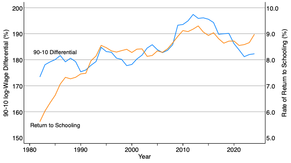

Earnings inequality and the Return to Schooling

```stata
. line ldiff year, yaxis(1) || line grade_coef year, yaxis(2) ///
>  xtitle(Year) xlabel(1980(10)2025) xtick(1980(5)2015) ///
>  ytitle("90-10 log-Wage Differential (%)", axis(1)) ylabel(150(10)200, format(%10.0g) noticks axis(1)) ///
>  ytitle("Rate of Return to Schooling (%)", axis(2)) ylabel(5(1)10, noticks axis(2)) ///
>  text(183 1985 "90-10 Differential") text(155 1985 "Return to Schooling") ///
>  scheme(Wide727Scheme) name(g1, replace)
```

The striking feature of this graph is how closely the return to schooling tracks overall wage inequality, particularly from the mid-1990s onward. While the relationship is less clear in the 1980s, the parallel movement of these two measures over the past 25+ years tells us something important: education has become a crucial driver of earnings differences in the modern labor market. When the payoff to education rises, we see wider gaps between high and low earners, highlighting just how much schooling makes a difference to income.

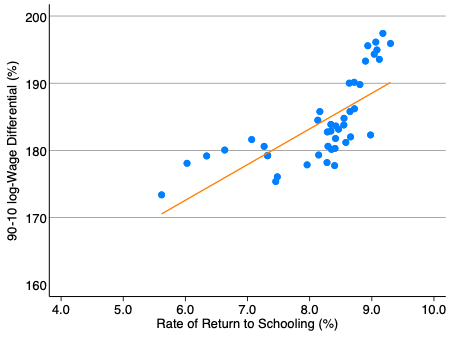

Earnings inequality and the Return to Schooling

```stata
. scatter ldiff grade_coef || lfit ldiff grade_coef ||, ///
>  xtitle(Rate of Return to Schooling (%)) xlabel(4(1)10) ///
>  ytitle("90-10 log-Wage Differential (%)") ylabel(160(10)200, format(%10.0g) noticks) ///
>  scheme(Squarish727Scheme) name(g2, replace)
```

The scatter plot reinforces this story, showing a clear positive relationship between returns to education and wage inequality.